# Reinforcement Learning

### *Charakteristiken von Reinforcement Learning*

- Kein Supervisor, nur ein Reward Signal
- Feedback erfolgt verzögert, nicht sofort
- Zeitabhängigkeit
- Aktionen des Agenten beeinflussen die Daten, die er erhält

### *Rewards*

- Eine Belohnung/Reward (Rt) ist ein skalares Feedback Signal
- Gibt an, wie gut der Agent bei Step t agiert
- Der Job des Agenten ist es den kumulativen Reward zu maximieren

**Reinforcement Learning basiert auf der „Reward-Hypothesis“**

**Alle Ziele können durch Maximieren des erwarteten cumulativen Rewards beschrieben werden**

### *Sequentielles Decision Making*

- Ziel: Auswahl von Maßnahmen zur Maximierung der zukünftigen Reward
- Maßnahmen können langfristige Folgen haben
- Belohnung kann sich verzögern
- Es kann besser sein, die unmittelbare Belohnung zu opfern, um eine langfristige Belohnung zu erhalten

### *Markov Decision Process*

Der Markov Decision Process muss die Anforderungen einer Markov Property erfüllen!

*Markov Property requires that “the future is independent of the past given the present”*

**Formel**

$P(X_{t+1} = s | X_t = s_{t} , X_{t−1} = s_{t−1}, . . . , X_0 = s_0) = P(X_{t+1} = s | X_t = s_t)$

*Erklärung zur Formel:*

**$X_t$ ist abhängig von X aber ist nicht abhängig von $X_{t-1},..., X_1, X_0$**

### *Zustandsübergangswahrscheinlichkeit (State Transition Probability)*

Annahme: Wir befinden uns in Status s. Die State Transition Probability gibt nun an mit welcher Wahrscheinlichkeit der nächste Status $s_+1$ eintreten wird.

**Formel:**

$P_{ss'} = P[S_{s+1} = s']| S_t = s$

Zusätzlich können alle Zustandsübergänge in einer Übergangsmatrix angezeigt werden:

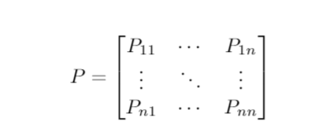

Jede Reihe zegit die Zustandsübergangswahrscheinlichkeiten von einem Status zu allen anderen möglichen Status.

### *Markov Process / Markov Chain*

- Sequenz von zufälligen Status mit Markov Property

Wir definieren hier folgende Parameter:

- S: endliches Set aus Status
- P : Zustandsübertragsungswahrscheinlichkeiten welcher als Matrix festgelegt wird.

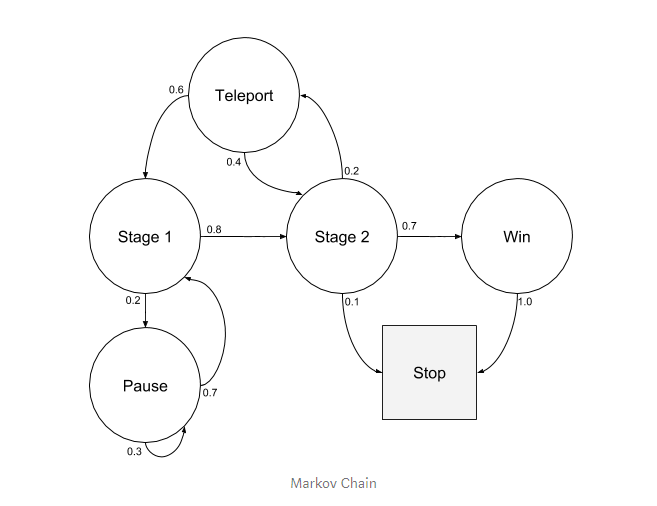

Die entsprechenden State Transition Probabilites dazu:

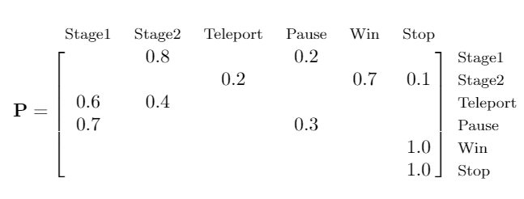

## *Markov Chain mit vorhandenen Regen Daten*

### *Erstellen der Transition Matrix*

```r
data(rain)
mysequence<-rain$rain
createSequenceMatrix(mysequence)
```

```
##       0 1-5  6+
## 0   362 126  60
## 1-5 136  90  68
## 6+   50  79 124
```

```r
head(rain)
```

```
##   V1 rain
## 1  3   6+
## 2  2  1-5
## 3  2  1-5
## 4  2  1-5
## 5  2  1-5
## 6  2  1-5
```

```r
myFit<-markovchainFit(data=mysequence,confidencelevel = .9,method = "mle")
myFit
```

```
## $estimate
## MLE Fit
##  A  3 - dimensional discrete Markov Chain defined by the following states:
##  0, 1-5, 6+
##  The transition matrix  (by rows)  is defined as follows:
##             0       1-5        6+
## 0   0.6605839 0.2299270 0.1094891
## 1-5 0.4625850 0.3061224 0.2312925
## 6+  0.1976285 0.3122530 0.4901186
##
##
## $standardError
##              0        1-5         6+
## 0   0.03471952 0.02048353 0.01413498
## 1-5 0.03966634 0.03226814 0.02804834
## 6+  0.02794888 0.03513120 0.04401395
##
## $confidenceLevel
## [1] 0.9
##
## $lowerEndpointMatrix
##             0       1-5         6+
## 0   0.6034754 0.1962346 0.08623909
## 1-5 0.3973397 0.2530461 0.18515711
## 6+  0.1516566 0.2544673 0.41772208
##
## $upperEndpointMatrix
##             0       1-5        6+
## 0   0.7176925 0.2636194 0.1327390
## 1-5 0.5278304 0.3591988 0.2774279
## 6+  0.2436003 0.3700386 0.5625151
##
## $logLikelihood
## [1] -1040.419
```

```r
alofiMc<-myFit$estimate
alofiMc
```

```
## MLE Fit
##  A  3 - dimensional discrete Markov Chain defined by the following states:
##  0, 1-5, 6+
##  The transition matrix  (by rows)  is defined as follows:
##             0       1-5        6+
## 0   0.6605839 0.2299270 0.1094891
## 1-5 0.4625850 0.3061224 0.2312925
## 6+  0.1976285 0.3122530 0.4901186
```

```r
a11=alofiMc[1,1]
a12=alofiMc[1,2]
a13=alofiMc[1,3]
a21=alofiMc[2,1]
a22=alofiMc[2,2]
a23=alofiMc[2,3]
a31=alofiMc[3,1]
a32=alofiMc[3,2]
a33=alofiMc[3,3]

## Hard code the transition matrix
stateNames <- c("Kein Regen","Leichter Regen","Schwerer Regen")
ra <- matrix(c(a11,a12,a13,a21,a22,a23,a31,a32,a33),nrow=3, byrow=TRUE)
#ra <- matrix(c(0.660,0.230,0.110,0.463,0.306,0.231,0.198,0.312,0.490),nrow=3, byrow=TRUE)

dtmcA <- new("markovchain",transitionMatrix=ra, states=c("Kein Regen","Leichter Regen","Schwerer Regen"), name="MarkovChain A")

dtmcA
```

```
## MarkovChain A
##  A  3 - dimensional discrete Markov Chain defined by the following states:
##  Kein Regen, Leichter Regen, Schwerer Regen
##  The transition matrix  (by rows)  is defined as follows:
##                Kein Regen Leichter Regen Schwerer Regen
## Kein Regen      0.6605839      0.2299270      0.1094891
## Leichter Regen  0.4625850      0.3061224      0.2312925
## Schwerer Regen  0.1976285      0.3122530      0.4901186
```

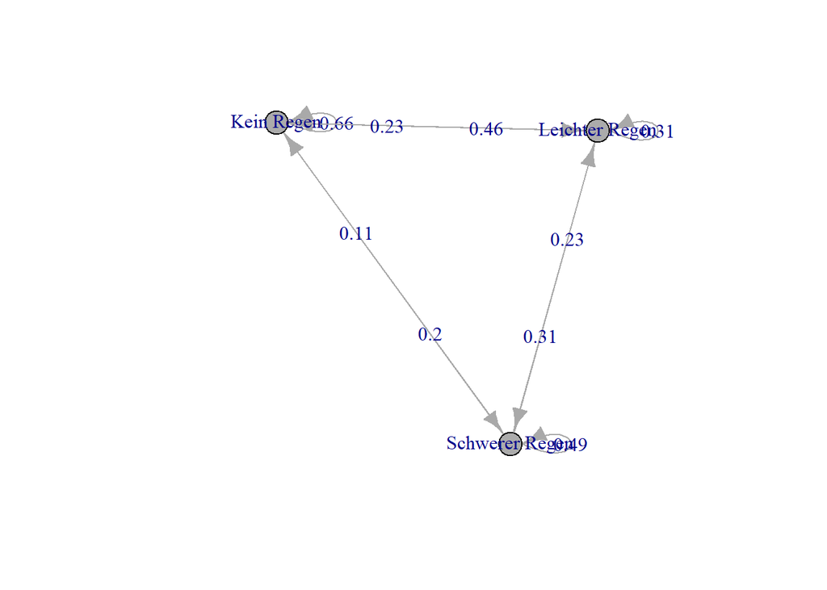

```r
plot(dtmcA)
```

### *Plotmat Diagramm zur besseren Übersichtlichkeit*

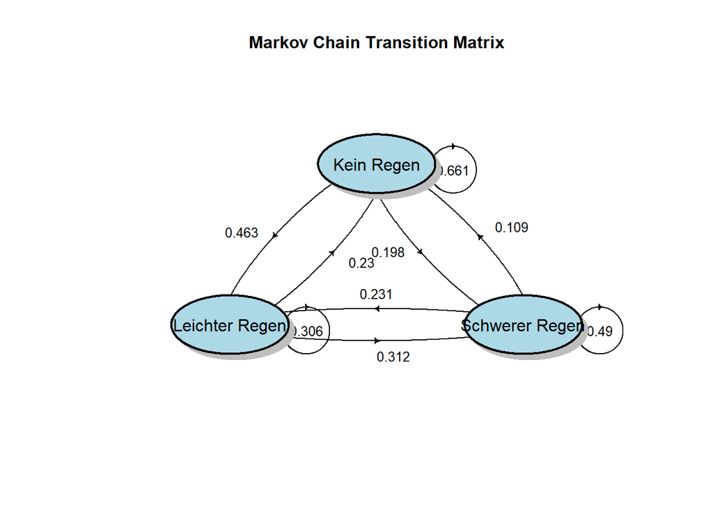

```r
row.names(ra) <- stateNames; colnames(ra) <- stateNames
ra = round(ra,3)
plotmat(ra,pos = c(1,2),
        lwd = 1, box.lwd = 2,
        cex.txt = 0.8,
        box.size = 0.1,
        box.type = "circle",
        box.prop = 0.5,
        box.col = "light blue",
        arr.length=.1,
        arr.width=.1,
        self.cex = .4,
        self.shifty = -.01,
        self.shiftx = .13,
        main = "Markov Chain Transition Matrix")
```

### *Feststellung des aktuellen Status*

```r
##Wir gehen davon aus dass es heute nicht regnet!
x1 <- matrix(c(1,0,0),nrow=1, byrow=TRUE)
```

### *Feststellung ob es morgen regnen wird*

```r
x1 %*% ra
```

```
##      Kein Regen Leichter Regen Schwerer Regen
## [1,]      0.661           0.23          0.109
```

### *Vorraussage des Wetters für die nächsten 7 Tage*

```r
ra2 <- ra %^% 2
ra3 <- ra %^% 3
ra4 <- ra %^% 4
ra5 <- ra %^% 5
ra6 <- ra %^% 6
ra7 <- ra %^% 7
cat("Vorhersage Tag 1")
```

```
## Vorhersage Tag 1
```

```r
round(x1%*%ra,3)
```

```
##      Kein Regen Leichter Regen Schwerer Regen
## [1,]      0.661           0.23          0.109
```

```r
cat("Vorhersage Tag 2")
```

```
## Vorhersage Tag 2
```

```r
round(x1%*%ra2,3)
```

```
##      Kein Regen Leichter Regen Schwerer Regen
## [1,]      0.565          0.256          0.179
```

```r
cat("Vorhersage Tag 3")
```

```
## Vorhersage Tag 3
```

```r
round(x1%*%ra3,3)
```

```
##      Kein Regen Leichter Regen Schwerer Regen
## [1,]      0.528          0.264          0.208
```

```r
cat("Vorhersage Tag 4")
```

```
## Vorhersage Tag 4
```

```r
round(x1%*%ra4,3)
```

```
##      Kein Regen Leichter Regen Schwerer Regen
## [1,]      0.512          0.267          0.221
```

```r
cat("Vorhersage Tag 5")
```

```
## Vorhersage Tag 5
```

```r
round(x1%*%ra5,3)
```

```
##      Kein Regen Leichter Regen Schwerer Regen
## [1,]      0.506          0.268          0.226
```

```r
cat("Vorhersage Tag 6")
```

```
## Vorhersage Tag 6
```

```r
round(x1%*%ra6,3)
```

```
##      Kein Regen Leichter Regen Schwerer Regen
## [1,]      0.503          0.269          0.228
```

```r
cat("Vorhersage Tag 7")
```

```
## Vorhersage Tag 7
```

```r
round(x1%*%ra7,3)
```

```
##      Kein Regen Leichter Regen Schwerer Regen
## [1,]      0.502          0.269          0.229
```

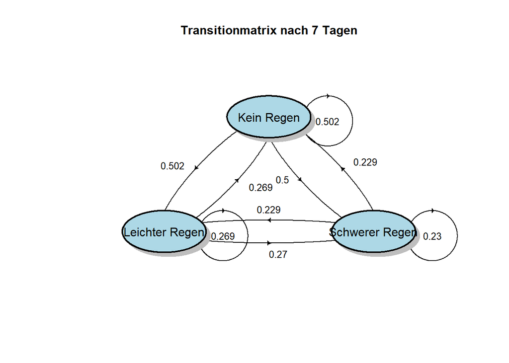

```r
ra7=round(ra7,3)

plotmat(ra7,pos = c(1,2),
        lwd = 1, box.lwd = 2,
        cex.txt = 0.8,
        box.size = 0.1,
        box.type = "circle",
        box.prop = 0.5,
        box.col = "light blue",
        arr.length=.1,
        arr.width=.1,
        self.cex = .6,
        self.shifty = -.01,
        self.shiftx = .14,
        main = "Transitionmatrix nach 7 Tagen")
```

## *Markov Reward Process*

Wir können in den Beispielen eindeutig sehen, das wir bisher noch nicht mit dem sog. Reward gearbeitet haben.

Aus diesem Grund implementieren wir nun einen Reward Value in unsere Markov Chain und definieren wieder unsere Parameter:

*S: endliches Set aus Status* P: Zustandsübertragungswahrscheinlichkeiten *R: Reward* Gamma:$\gamma$ Discount Faktor

**Unser Ziel sollte es sein, den Return Value zu maximieren!**

**Formel:**

$G_t = R_{t+1} + \gamma R_{t+2} + ...$

*$G_t$ wird auf Basis einer zufälligen Sample Sequence berechent*

Daraus ergibt sich wiederum folgende Markov Chain:

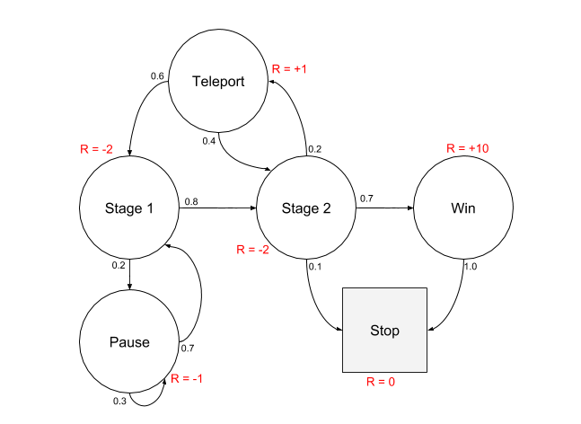

## Value Funktion für den Markov Reward Process

**Formel:**

$v(s) = E[G_t|S_t = s]$

Wir durchlaufen hier also verschiedene Stadien mit unterschiedlichen Samples. Ziel hiervon ist es, festzustellen, welche Status den höchsten approximierten Reward bieten.

Die nachfolgende Grafik dient zur Veranschaulichung der Value Funktion:

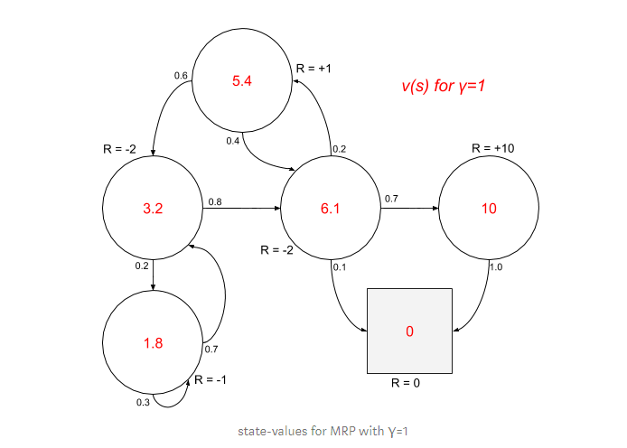

Die Value Funktion können wir auf zwei elementare Teile herunterbrechen:

- Immediate Reward: $R_{t+1}$
- Gamma: $\gamma$

Mithilfe dieser beiden Informationen können wir die bereits existierende Value Funktion erweitern:

**Formel:**

$v(s) = R_s + \gamma \sum_{s'\in S} P_{ss'}v(s')$

## Markov Reward Process Beispiel

Wir denken uns folgendes Beispiel aus. Der Agent soll auf die Suche nach dem Ziel sein. Der Agent kann sich in einem 2x2 Grid frei bewegen.

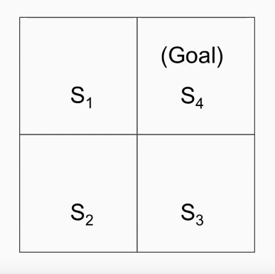

```r
#?gridworldEnvironment
env <- gridworldEnvironment
print(env)
```

```
## function (state, action)
## {
##     next_state <- state
##     if (state == state("s1") && action == "down")
##         next_state <- state("s2")
##     if (state == state("s2") && action == "up")
##         next_state <- state("s1")
##     if (state == state("s2") && action == "right")
##         next_state <- state("s3")
##     if (state == state("s3") && action == "left")
##         next_state <- state("s2")
##     if (state == state("s3") && action == "up")
##         next_state <- state("s4")
##     if (next_state == state("s4") && state != state("s4")) {
##         reward <- 10
##     }
##     else {
##         reward <- -1
##     }
##     out <- list(NextState = next_state, Reward = reward)
##     return(out)
## }
## <bytecode: 0x000000001be1fbb8>
## <environment: namespace:ReinforcementLearning>
```

```r
states <- c("s1", "s2", "s3", "s4")
states
```

```
## [1] "s1" "s2" "s3" "s4"
```

```r
actions <- c("up", "down","left", "right" )
actions
```

```
## [1] "up"    "down"  "left"  "right"
```

```r
data <- sampleExperience(N=1000, env = env, states = states, actions = actions)

head(data)
```

```
##   State Action Reward NextState
## 1    s1   down     -1        s2
## 2    s1     up     -1        s1
## 3    s4   down     -1        s4
## 4    s2   left     -1        s2
## 5    s3   down     -1        s3
## 6    s3   left     -1        s2
```

```r
control <- list(alpha = 0.1, gamma = 0.5, epsilon = 0.1)
control
```

```
## $alpha
## [1] 0.1
##
## $gamma
## [1] 0.5
##
## $epsilon
## [1] 0.1
```

```r
#?ReinforcementLearning
model <- ReinforcementLearning(data, s = "State", a = "Action", r = "Reward", s_new = "NextState", control = control)
print(model)
```

```
## State-Action function Q
##         right         up       down       left
## s1 -0.8054262 -0.7932270  0.5981072 -0.7627094
## s2  3.5480173 -0.7852051  0.7146118  0.7284821
## s3  3.5509246  9.1087762  3.5129579  0.7199021
## s4 -1.8692620 -1.8787297 -1.8487538 -1.8754679
##
## Policy
##      s1      s2      s3      s4
##  "down" "right"    "up"  "down"
##
## Reward (last iteration)
## [1] -175
```